# Selected timers description

## 1. .NET Stopwatch.GetTimestamp Method

Documentation: https://learn.microsoft.com/en-us/dotnet/api/system.diagnostics.stopwatch.gettimestamp?view=net-10.0  
The script is available in the `c-sharp-timer\Program.cs` file.  
The command to build the .NET project: `dotnet build` inside the project directory

In [103]:

```
import pandas as pd
import matplotlib.pyplot as plt

path = './result-data/c-sharp-timer-results-nanoseconds.csv'
path_warmup = './result-data/c-sharp-timer-results-nanoseconds-warmup.csv'

df = pd.read_csv(path, header=None, names=['timestamp_ns'])
df_warmup = pd.read_csv(path_warmup, header=None, names=['timestamp_ns'])
```

In [104]:

```
def plot_timer_results(df, title):
    plt.figure(figsize=(12, 6))
    plt.plot(df.index, df["timestamp_ns"], marker=".", linestyle="-")
    plt.xlabel("Sample")
    plt.ylabel("timestamp_ns")
    plt.title(title)
    plt.grid(True, alpha=0.3)
    plt.tight_layout()
    plt.show()

plot_timer_results(df_warmup, "Stopwatch.GetTimestamp Warm Up results")
plot_timer_results(df, "Stopwatch.GetTimestamp results")
```

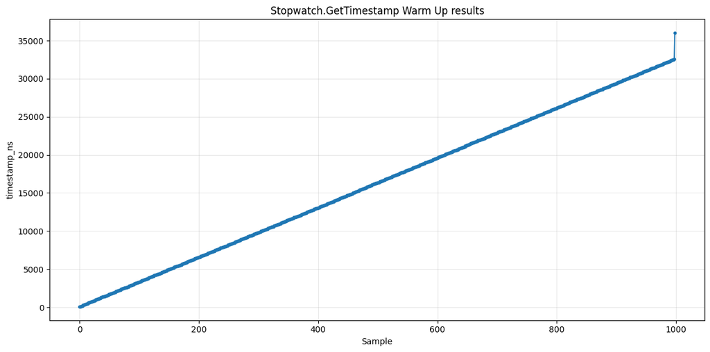

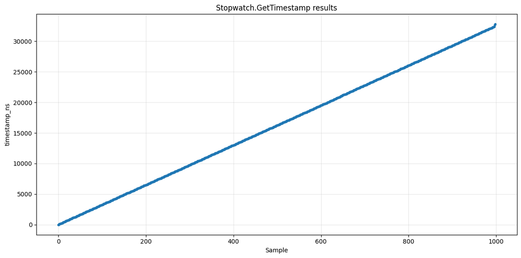

In [105]:

```
def plot_zoomed_area(df, zoom_start, zoom_end, multiple_locator=None, title="Stopwatch.GetTimestamp results (zoomed area)", figsize=(12, 6)):
    zoom_df = df.iloc[zoom_start:zoom_end]

    fig, ax = plt.subplots(figsize=figsize)
    ax.plot(zoom_df.index, zoom_df["timestamp_ns"], marker=".", linestyle="-")
    ax.set_xlabel("Sample")
    ax.set_ylabel("timestamp_ns")
    ax.set_title(title)
    ax.grid(True, alpha=0.3)

    if (multiple_locator is not None):
        ax.yaxis.set_major_locator(plt.MultipleLocator(multiple_locator))

    plt.tight_layout()
    plt.show()


plot_zoomed_area(df, 90, 200, 100)
plot_zoomed_area(df, 900, 1000, 100)
plot_zoomed_area(df_warmup, 980, 1000, 100, "Zoomed area for warmup results")
```

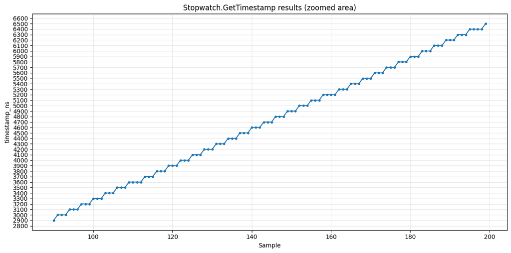

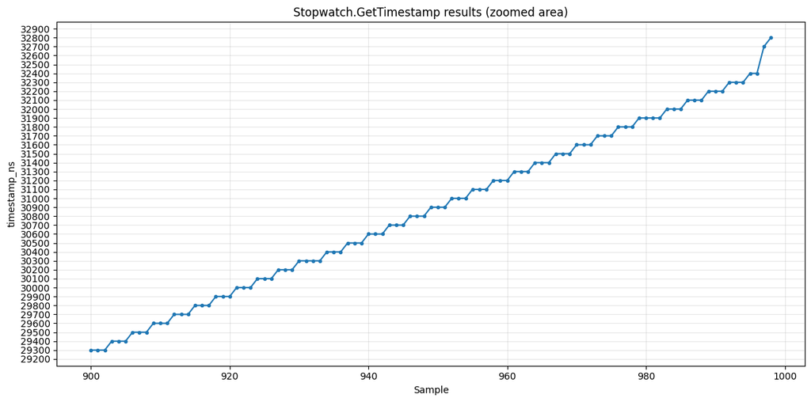

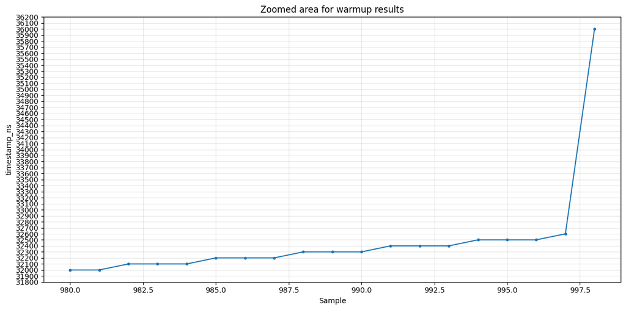

In [106]:

```
def calculate_access_overhead(df):
    values = df["timestamp_ns"]
    adjacent_differences = values.diff().dropna()
    sum_of_adjacent_differences = adjacent_differences.sum()
    average_value = sum_of_adjacent_differences / len(adjacent_differences)

    print(f"Number of adjacent differences: {len(adjacent_differences)}")
    print(f"Sum of adjacent differences: {sum_of_adjacent_differences}")
    print(f"Average of access overhead: {average_value} ns")

calculate_access_overhead(df)
```

Number of adjacent differences: 998 Sum of adjacent differences: 32800.0 Average of access overhead: 32.86573146292585 ns

### The resolution of the timers (related to units returned)

To determine the resolution we can use the Frequency field of the timer: https://learn.microsoft.com/en-us/dotnet/api/system.diagnostics.stopwatch.frequency?view=net-10.0#system-diagnostics-stopwatch-frequency. The documentation says that:  
"The Frequency value depends on the resolution of the underlying timing mechanism. If the installed hardware and operating system support a high-resolution performance counter, then the Frequency value reflects the frequency of that counter. Otherwise, the Frequency value is based on the system timer frequency."  
It means that the result depend on the underlying system.  
To deternime resolution, we will print to console value of the frequency field. In my case it is equal to 10_000_000 ticks per second. 1 second contains 1 billion nanoseconds, so it means that the resolution of a timer is 100ns. This is also confirmed experimentaly - all the measured time differences are dividable by 100.

### The granularity of the timers (related to minimum increment)

The minimal increment is 100 ns, so the granularity is 100 ns.

### The overhead of the timer access (related to minimum delta)

The overhead of the timer access is smaller than the resolution, because we can get the same timer value during a couple of accesses in a sequence. It is worth to mention that this accesses number for which the results do not change is not stable - sometimes it is 3, sometimes it is 4 or even 6.  
Therefore, to calculate the overhean, we will sum up all the differences and divide them by their number. This will allow us to gain the average overhead. The value was presented in the above calculations.

### The stability of the timer (both during and after warm up)

We can see that the timer is stable during and after warmup except the last measurments.

### The overflow period of the timer

The inspected method returns `long` value that represents the numbers of ticks. The max value of `long` is 9,223,372,036,854,775,807 (https://learn.microsoft.com/en-us/dotnet/csharp/language-reference/builtin-types/integral-numeric-types)

In [107]:

```
frequency = 10_000_000
max_seconds = 9_223_372_036_854_775_807 / frequency
max_minutes = max_seconds / 60
max_hours = max_minutes / 60
max_days = max_hours / 24
max_years = max_days / 365.25

print(f"Max days: {max_days:.2f}")
print(f"Max years: {max_years:.2f}")
```

Max days: 10675199.12 Max years: 29227.10

By performing simple calculations we can see that the time, we need to see the timer overflow is large enough and it is imposible to investigate what happens during it experimentally

## 2. SYSDATETIME (Transact-SQL)

Documentation: https://learn.microsoft.com/en-us/sql/t-sql/functions/sysdatetime-transact-sql?view=sql-server-ver17  
The script is available in the `sql-timer\SQLQuery1.sql` file.

In [108]:

```
path = './result-data/sql-timer-results.csv'

df_warmup = pd.read_csv(path, sep=';', header=None, usecols=[1], names=['timestamp_ns'])
df = pd.read_csv(path, sep=';', header=None, usecols=[2], names=['timestamp_ns'])
```

In [109]:

```
plot_timer_results(df_warmup, "SYSDATETIME Warm Up results")
plot_timer_results(df, "SYSDATETIME results")
```

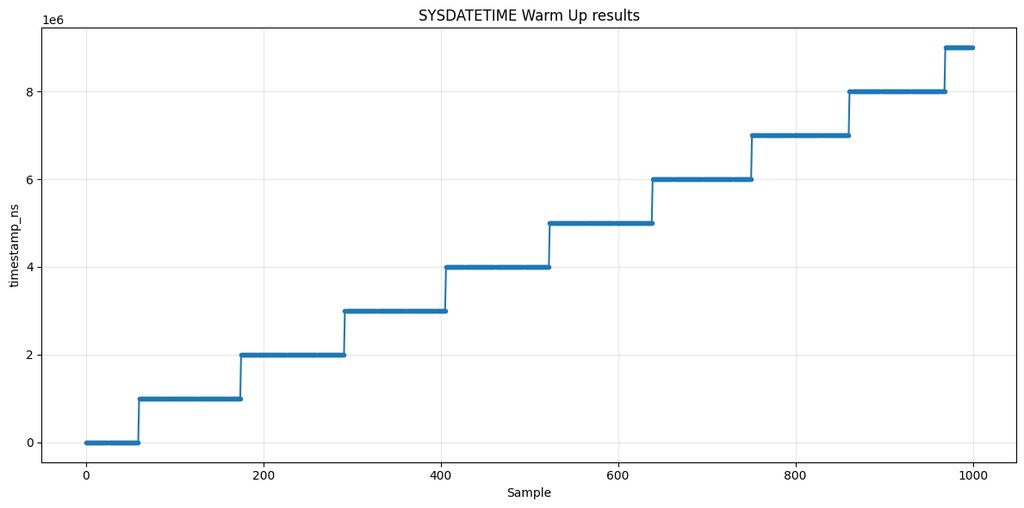

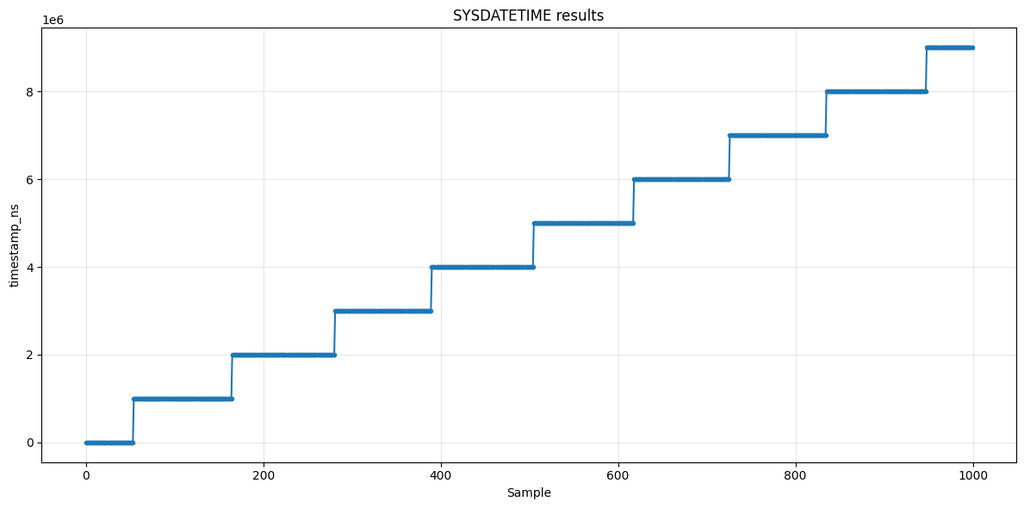

In [110]:

```
plot_zoomed_area(df, 100, 200, None, "SYSDATETIME results (zoomed area)", figsize=(12, 4))
plot_zoomed_area(df, 850, 1000, None, "SYSDATETIME results (zoomed area)", figsize=(12, 4))
plot_zoomed_area(df_warmup, 900, 1000, None, "Zoomed area for warmup results", figsize=(12, 4))
```

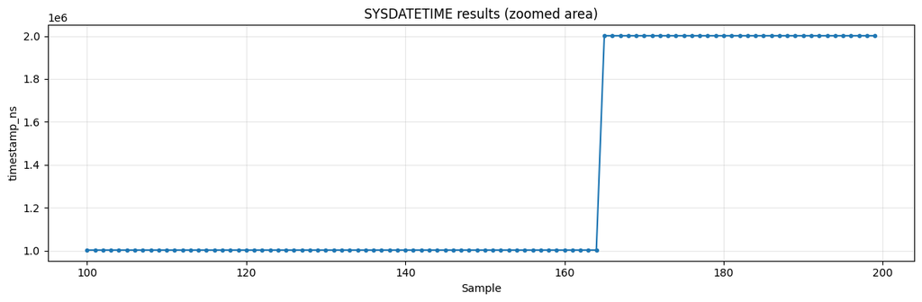

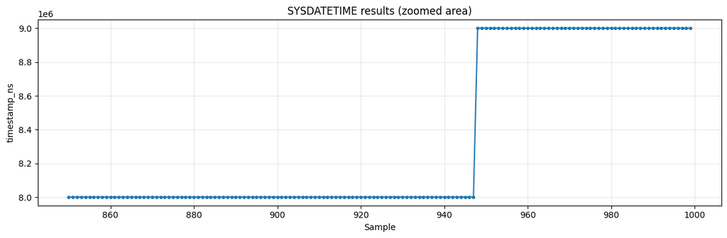

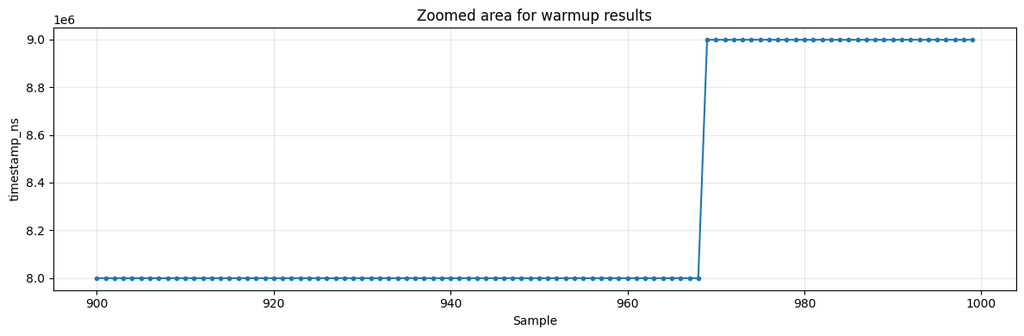

### The resolution of the timers (related to units returned)

The resolution for the timer depends on the value type SYSDATETIME function can return. It returns DATETIME2(7): https://learn.microsoft.com/en-us/sql/t-sql/data-types/datetime2-transact-sql?view=sql-server-ver17 which is stored in a temporary table variable. 7 in the DATETIME2(7) indicates the precision. In the documentation we see `Accuracy 100 nanoseconds`, so the resolution for the timer is 100 nanoseconds.  
In the experimental results we see that all the numbers are dividable by 100 but not 1000, so it prooves that the resolution is 100 ns.

### The granularity of the timers (related to minimum increment)

Let's find the minimal increment:

In [111]:

```
def calculate_minimum_increment(df):
    values = df["timestamp_ns"]
    adjacent_differences = values.diff().dropna()
    adjacent_differences = adjacent_differences[adjacent_differences > 0]
    min_of_adjacent_differences = adjacent_differences.min()

    print(f"Minimum of adjacent differences: {min_of_adjacent_differences}")

calculate_minimum_increment(df)
```

Minimum of adjacent differences: 999100.0

So, experimentally, we can see that the minimum increment for SYSDATETIME is around 1 millisecond.

### The overhead of the timer access (related to minimum delta)

In [112]:

```
calculate_access_overhead(df)
```

Number of adjacent differences: 999 Sum of adjacent differences: 9000900.0 Average of access overhead: 9009.90990990991 ns

The overhead for iteration is 9009.9 ns. But we need to take into account that in SQL there is no way to preallocate space as for some other programming languages, so the part of the overhead depends on the INSERT time as well.

### The stability of the timer (both during and after warm up)

From the plots we see that the timer is stable both during and after warm up

### The overflow period of the timer

The DATEDIFF_BIG returns `Signed bigint` value which can store 9,223,372,036,854,775,807 as a maximum possible value. So to go from 0 to it we will need the similar number of years as for .NET method. https://learn.microsoft.com/en-us/sql/t-sql/functions/datediff-big-transact-sql?view=sql-server-ver17#return-type  
As for the DATETIME2, the maximum posible date it can store is 9999-12-31 https://learn.microsoft.com/en-us/sql/t-sql/data-types/datetime2-transact-sql?view=sql-server-ver17  
So these limits will not allow us to check what will happen during overflow experimentally.